# 01_イントロダクション

k-ishikawa@g.ecc.u-tokyo.ac.jp

2023-10-09

## **授業について**

統計ソフトウェアRおよび統合開発環境RStudio（クラウド版RStudio Cloud）を用いた計量経済分析

https://www.r-project.org/.

https://posit.co/download/rstudio-desktop/.

[figure not shown]

https://login.rstudio.cloud/login.

### なぜRなのか？

- 無償のオープンソースウェア
- 計量経済分析に必要な道具がひととおり揃っている
- ユーザーが多い（困ったら人に聞ける）
  - [Qiita](https://qiita.com/)
  - [stack overflow](https://ja.stackoverflow.com/)
  - [reddit](https://www.reddit.com/r/ja/)
  - などのコミュニティにおいてQ&Aが充実している（ただし英語サイトの方が圧倒的にユーザー数が多い）
- 他の統計ソフトと比べてどう？
  - Stata: 有償. 計量経済学ではRと同じく人気. 操作感がシンプルでトラブルが少ない.
  - EViews: 有償. GUIが充実していてコーディングしなくてもよい. 時系列分析に強い.
  - Python: 無償. Rと同じく開発者コミュニティが充実. 自然言語処理, 画像認識, 機械学習などの先進分野に強い.

### 授業のスケジュール

| 授業回 | テーマ | 詳細 |
| --- | --- | --- |
| 01回（10/9） | イントロダクション | 授業ガイダンス, RStudioの導入と基本操作 |
| 02回（10/16） | データ構造 | Rにおけるデータ構造 |
| 03回（10/23） | データ抽出 | 基本関数を用いたデータ抽出 |
| 04回（10/30） | tidyverseによるデータ加工① | データ読込方法, dplyrの導入 |
| 05回（11/6） | tidyverseによるデータ加工② | dplyrの応用 |
| 06回（11/13） | ggplot2による可視化 | ggplot2によるグラフの作成 |
| 07回（11/20） | 回帰分析（記述統計） | 最小二乗法（OLS）, 推定結果の可視化 |
| 08回（12/4） | 仮説検定Ⅰ | 因果推論の基礎, 仮説検定のフレームワーク |
| 09回（12/11） | 仮説検定Ⅱ | 平均値の差の検定, 仮説検定の注意点 |
| 10回（12/18） | 回帰分析（推測統計）Ⅰ | 欠落変数バイアス（OVB）とコントロール変数 |
| 11回（12/25） | 回帰分析（推測統計）Ⅱ | 対数変換, 他の内生性バイアス（同時決定性バイアス） |
| 12回（1/15） | 回帰分析と因果推論 | 操作変数（IV）法, 二段階最小二乗（TSLS）法 |
| 13回（1/22） | 予備日（休講予定） |  |
| 14回（1/29） | 期末試験 |  |

### 成績評価の方法

- 平常点（課題）：30%
- 期末試験：70%
- いずれもITC-LMSに提出
- 優/良/可/不可の評価は農学部学務関係内規に従う

### 自己紹介

**石川 清貴**（k-ishikawa@g.ecc.u-tokyo.ac.jp）

- 2014~2017: 農林水産省 行政技官
- 2018~2020: 東京大学大学院農学生命科学研究科農業・資源経済学 博士課程（経済学研究室）
- 2020~2021: 同大学院 農学特定研究員
- 2022~現在 : 駿河台大学経済経営学部 専任講師（食料経済学研究室）

## **RStudio Cloudの導入**

- [RStudio Cloud](https://login.rstudio.cloud/)から利用登録
- Cloud版とデスクトップ版は何が違うの？
  - これから登録するのはCloud Freeプラン
  - 利用時間は月に25時間まで
  - プロジェクト（後述）は25まで
  - PCのスペックをフルに使えない（RAM 1GB/1CPU/Max Execution 1h）
  - デスクトップ版にこうした制約はないが、ECCS端末にインストールできない
- **Sign Up**からユーザー登録
  - いろいろ方法はあるが**Sign Up with Google**からECCSアカウントで登録するのが一番簡単

[figure not shown]

- 登録したら**Posit Cloud**を選択

[figure not shown]

- Work Spaceが表示されるがまだ何もない

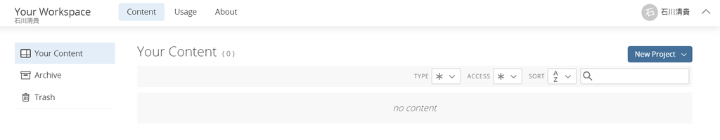

- 右上の**New Project**から**New RStudio Project**を選択

[figure not shown]

- Rプロジェクトのホーム画面が表示される
  - **プロジェクト名**を適当に変える
  - 例えば, aqeaなど英数字の方がトラブルが少ない
  - 授業回ごとにプロジェクトを新設してもよいが, 上限数が減る

[figure not shown]

## **設定と基本操作**

- お好みのフォントやテーマに設定
  - **Tools**タブから**Global Options**を選択

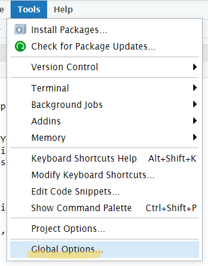

- **Appearance**からフォントやテーマを変更可能

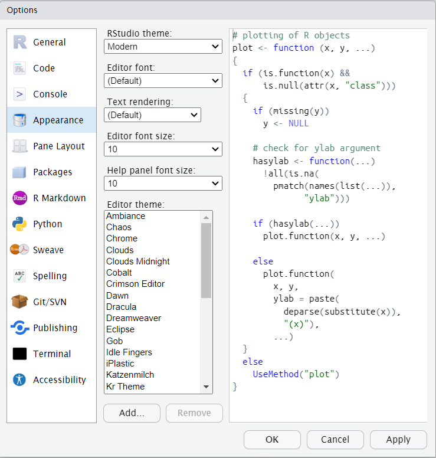

- **Pane Layout**から枠（Pane）のレイアウトを変更可能

[figure not shown]

- これから各**Pane**の役割と見方を説明
  - まず画面左上, **File**下に見える**＋アイコン**を選択
  - **R Script**を選択（Ctrl+Alt+Shift+N）

[figure not shown]

- 左上Paneに**Script**が表示される.
- ここに残したいコードを書き溜める.
  - 日本語や英語のコメントも可能（コマンドと区別するために文頭にハッシュタグ**#**をつけてコメントアウトする）.
  - 後で見返したとき, コマンドの意味を忘れていることが多いのでメモは重要

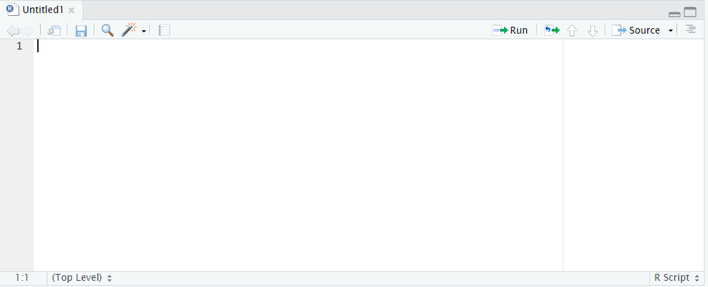

- 次に, 左下Paneにある**Console**でいろいろなコマンド（命令）を実行してみる.

[figure not shown]

- 試しに、このようなコマンドを書いて実行（Enter）してみよう.
  - 慣れるまでは, コピペではなく手を動かしてタイピング
  - 直下の行に答えが**[1] 2**と表示される.

```r
1+1
```

```
## [1] 2
```

- **Script**にこのようなコマンドをメモしてみよう.
  - ついでにファイル保存（Ctrl+S）しておく. 名前は適当に（例えば, 01）
  - スクリプト内でカーソルを当てているブロックだけ命令を実行（例えば3*6の行で**Ctrl+Enter**）
  - スクリプト内のコマンドをすべて実行（**Ctrl+Shift+Enter**）

```r
1+1
2-5
3*6
9/3
```

- 右下Paneの**Files**に保存したScriptファイルがあることを確認

[figure not shown]

## **演習**

### 関数

- **関数名（引数: argument）**が基本の形
- 以下のコマンドを実行してみよう.
  - 平方根 **sqrt**
  - 対数 **log**
  - 日付 **date**

```r
sqrt(16)
log(2, base=10)
date()
```

### 代入

- 変数に値を代入する際は、イコールではなく**<-**
- 以下のコマンドを実行してみよう.

```r
a <- 1
b <- 1
c <- -1
(b + sqrt(b^2-4*a*c))/(2*a)
```

### コメントアウト

- 何を目的としたコマンドなのか、**#コメント**でリマインド
- 以下のコマンドを実行してみよう.

```r
(b + sqrt(b^2-4*a*c))/(2*a) #二次方程式の解
```

### ベクトル

- 型・長さ・属性をもつ.
- まずは, **アトミックベクトル**
- 変数xに３つの値（1, 2.5, 4.5）を要素とするベクトルを代入してみよう.
  - combine/concatenate **c**

```r
x <- c(1, 2.5, 4.5)
```

- 右上Paneの**Environment**に保存したxがあることを確認
  - **num**はnumeric（数値）型
  - **[1:3]**は長さが3
  - **1, 2.5, 4.5**は要素

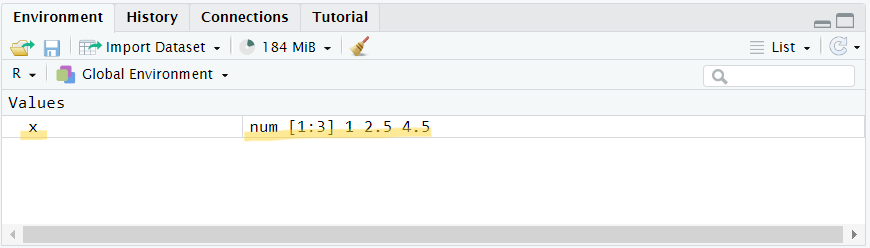

- 数値以外のベクトルもある.
- 調査項目には記述式や選択式, バイナリー式の設問もある.
  - 文字を引数に入力する際は, **““double quotation”“**で囲む.
  - はい/いいえを引数に入力する際は, **TRUE, FALSE**もしくは**T, F**
- 変数yおよびzに以下のベクトルを代入してみよう.

```r
y <- c("男性", "兵庫県", "大学院卒")
z <- c(TRUE, FALSE, T)
```

- 右上Paneの**Environment**に反映されたことを確認

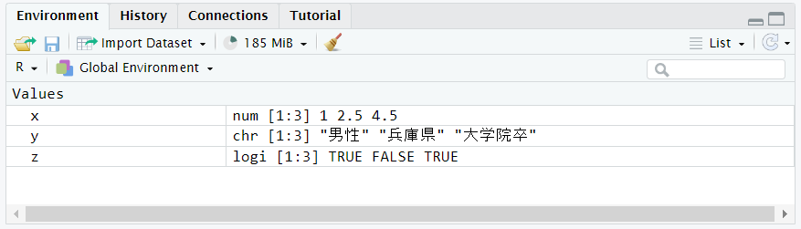

- アトミックベクトルの型一覧

| 型 | Rの名称 | 例 |
| --- | --- | --- |
| 数値型（倍精度小数点型） | numeric(double) | 1, 2.5, 4.5 |
| 数値型（整数型） | numeric(integer) | 1L, 3L, 5L |
| 文字型 | character | “男性”, “兵庫県”, “大学院卒” |
| 論理型 | logical | TRUE, FALSE,T |

### 型の判定

- Rでは, 変数の型によりコマンドの幅が異なる.
  - 何かエラーが出たら, まずは変数の型を確認しよう.
  - 変数の型を返す **typeof**
  - 変数が○○であるかを返す **is.double, is.integer, is.numeric, is.atomic**
- 変数xに以下のコマンドを実行してみよう.

```r
typeof(x)
is.double(x)
is.integer(x)
is.numeric(x)
is.atomic(x)
```

### 型の変換

- 既存の変数を別の型に変えたい場合もある.
  - 例えば, 回帰分析では論理型（TRUE, FALSE）はダミー変数（1,0）に変える.
  - 変数の型を○○型に変える **as.numeric, as.character**
- 変数zに以下のコマンドを実行してみよう.

```r
z <- as.numeric(z)
```

### リスト

- ベクトルにはアトミックベクトルの他に**リスト**がある.
- 引数には異なる型の数値や文字, アトミックベクトルを入力可能
  - 引数をリスト化 **list**
- 以下のコマンドを実行してみよう.

```r
l_a <- list(1, "a", c(1, 2.5, 4.5), c(TRUE, FALSE, T))
```

- 右上Paneの**Environment**に反映されたことを確認

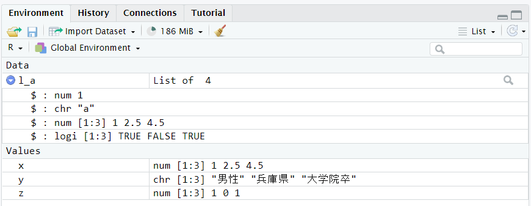

- リストをアトミックベクトルに変換することもできる.
  - リストのアトミックベクトル化 **unlist**
- 以下のコマンドを実行してみよう.

```r
unlist(l_a)
```

- ちなみに, 関数をコマンドするだけでは変数そのものは変化しない.
- 変数l_aをアトミックベクトルに変えたい場合は, l_aを再定義する.
  - この場合, l_aの要素はその中で最も柔軟性の高い型に統一される.
  - 型の柔軟性は, **論理型＜整数型＜倍精度小数点型＜文字列型**

```r
l_a <- unlist(l_a)
```

### 変数の消去

- 特定の変数を消去する.
  - 消去 **remove, re**
- 以下のコマンドを実行してみよう.

```r
remove(l_a)
```

- すべての変数を消去したい場合は**Environment**の**ほうきアイコン**

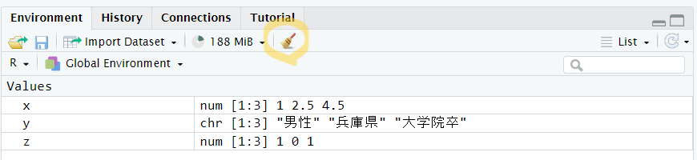

## **課題**

- 初回は課題なし
- 次回からはITC-LMSに課題をアップロード